# simon-5501-09-slides

2026-10-20

## Topics to be covered

- What you will learn
  - Restructuring your data
  - One-tailed tests
  - Checking assumptions
  - Alternative tests
  - R code for alternative tests
  - Paired data
  - R code for paired data
  - Your homework

## Two different data structures

- Wide format (two columns)
  - Group 1 in first column
  - Group 2 in second column
- Long format (one column)
  - Group 1 in first $n_1$ rows of column
  - Group 2 in next $n_2$ rows of column
  - Could be different order or mixed
  - Additional column for group code

## Hypothetical data in the wide format

```r
wide_form
```

```
# A tibble: 4 × 2
    trt   pbo
  <dbl> <dbl>
1    15    34
2    13    31
3    18    36
4    19    NA
```

## Pivoting from wide form to long form

```r
wide_form |>
  pivot_longer(
    cols=c("trt", "pbo"),
    names_to="intervention",
    values_to="outcome") |>
  filter(!is.na(outcome))
```

```
# A tibble: 7 × 2
  intervention outcome
  <chr>          <dbl>
1 trt               15
2 pbo               34
3 trt               13
4 pbo               31
5 trt               18
6 pbo               36
7 trt               19
```

## Hypothetical data in the long format

```r
long_form
```

```
# A tibble: 8 × 3
     id result exposed
  <int>  <dbl> <chr>
1     1     45 n
2     2     43 n
3     3     48 n
4     4     49 n
5     1     64 y
6     2     61 y
7     3     66 y
8     4     62 y
```

## Pivoting from long form to wide form

```r
long_form |>
  pivot_wider(
    names_from=exposed,
    values_from=result)
```

```
# A tibble: 4 × 3
     id     n     y
  <int> <dbl> <dbl>
1     1    45    64
2     2    43    61
3     3    48    66
4     4    49    62
```

## Break #1

- What you have learned
  - Restructuring your data
- What’s coming next
  - One-tailed tests

## One-tailed tests, 1

- $H_0:\ \mu_1 - \mu_2 \le 0$
- $H_1:\ \mu_1 - \mu_2 > 0$
  - Accept $H_0$ if $\bar{X}_1-\bar{X}_2$ is large negative
  - Accept $H_0$ if $\bar{X}_1-\bar{X}_2$ is close to zero
  - Reject $H_0$ if $\bar{X}_1-\bar{X}_2$ is large positive
- More precisely,
  - Accept $H_0$ if $T \le t(1-\alpha, df)$
  - Reject $H_0$ if $T \gt t(1-\alpha, df)$

## Critical value for a one tailed test, 1

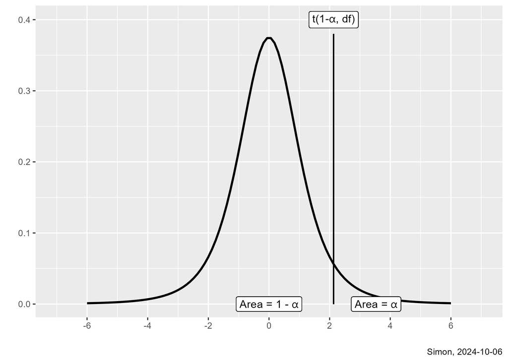

## One-tailed tests, 2

- $H_0:\ \mu_1 - \mu_2 \ge 0$
- $H_1:\ \mu_1 - \mu_2 < 0$
  - Reject $H_0$ if $\bar{X}_1-\bar{X}_2$ is large negative
  - Accept $H_0$ if $\bar{X}_1-\bar{X}_2$ is close to zero
  - Accept $H_0$ if $\bar{X}_1-\bar{X}_2$ is large positive
- More precisely,
  - Accept $H_0$ if $T \ge t(\alpha, df)$
  - Reject $H_0$ if $T \lt t(\alpha, df)$

## Critical value for the one-tailed test, 2

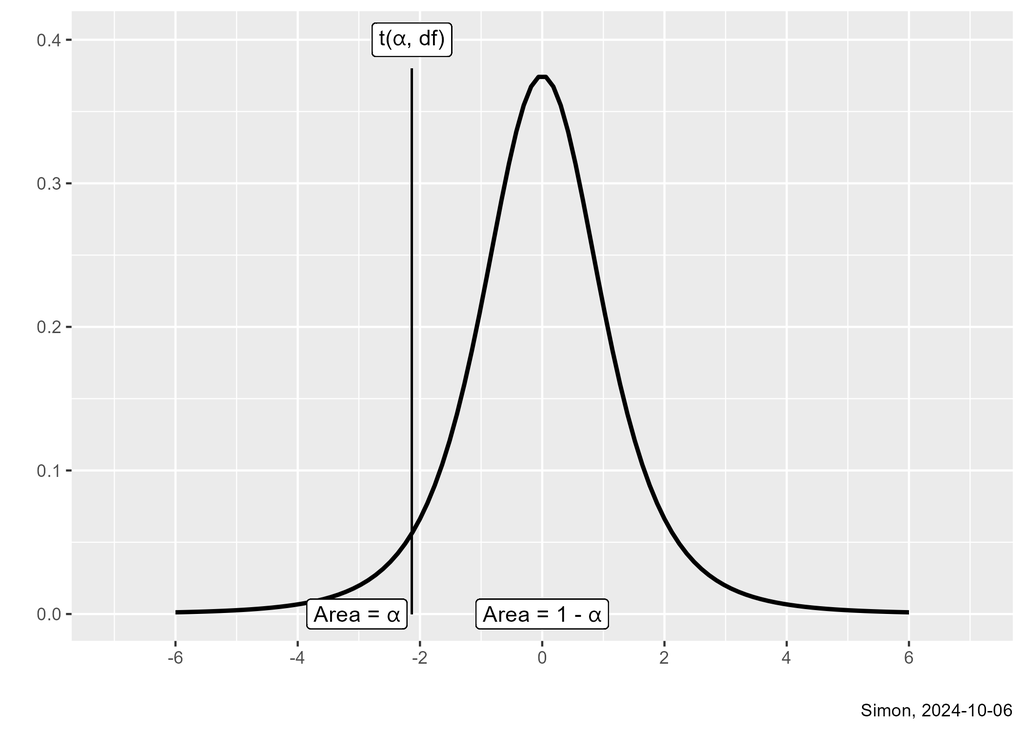

## Calculation of the p-value

- For testing $H_1:\ \mu_1 - \mu_2 \ne 0$
  - p-value = $2 P[t(n_1+n_2-2) > |T|]$
- For testing $H_1:\ \mu_1 - \mu_2 > 0$
  - p-value = $P[t(n_1+n_2-2) > T]$
- For testing $H_1:\ \mu_1 - \mu_2 < 0$
  - p-value = $P[t(n_1+n_2-2) < T]$
- For any of these hypothesis,
  - Accept $H_0$ if p-value > $\alpha$

## R code for one-sided hypotheses

- For testing $H_1:\ \mu_1 - \mu_2 \ne 0$
  - `alternative="two-sided"`
- For testing $H_1:\ \mu_1 - \mu_2 > 0$
  - `alternative="greater"`
- For testing $H_1:\ \mu_1 - \mu_2 < 0$
  - `alternative="less"`

## Break #2

- What you have learned
  - One-tailed tests
- What’s coming next
  - Checking assumptions

## Equivalence of the t-test and linear regression

```r
m1 <- t.test(
  fbsway ~ age,
  data=sway,
  var.equal=TRUE)
m2 <- lm(
  fbsway ~ age,
  data=sway)
```

## Output from t.test and lm

```r
m1
```

```
    Two Sample t-test

data:  fbsway by age
t = 2.2044, df = 15, p-value = 0.04353
alternative hypothesis: true difference in means between group Elderly and group Young is not equal to 0
95 percent confidence interval:
  0.2715453 16.1451214
sample estimates:
mean in group Elderly   mean in group Young
             26.33333              18.12500
```

```r
m2
```

```
Call:
lm(formula = fbsway ~ age, data = sway)

Coefficients:
(Intercept)     ageYoung
     26.333       -8.208
```

## Output from t.test and tidy

```r
m1
```

```
    Two Sample t-test

data:  fbsway by age
t = 2.2044, df = 15, p-value = 0.04353
alternative hypothesis: true difference in means between group Elderly and group Young is not equal to 0
95 percent confidence interval:
  0.2715453 16.1451214
sample estimates:
mean in group Elderly   mean in group Young
             26.33333              18.12500
```

```r
tidy(m2)
```

```
# A tibble: 2 × 5
  term        estimate std.error statistic      p.value
  <chr>          <dbl>     <dbl>     <dbl>        <dbl>
1 (Intercept)    26.3       2.55     10.3  0.0000000334
2 ageYoung       -8.21      3.72     -2.20 0.0435
```

## Output from t.test and confint

```r
m1
```

```
    Two Sample t-test

data:  fbsway by age
t = 2.2044, df = 15, p-value = 0.04353
alternative hypothesis: true difference in means between group Elderly and group Young is not equal to 0
95 percent confidence interval:
  0.2715453 16.1451214
sample estimates:
mean in group Elderly   mean in group Young
             26.33333              18.12500
```

```r
confint(m2)
```

```
                2.5 %     97.5 %
(Intercept)  20.88874 31.7779250
ageYoung    -16.14512 -0.2715453
```

## Population model for the two-sample t-test

- Population 1
  - $X_{11},X_{12},...,X_{1N_1}$
  - $X_{1i}$ are independent $N(\mu_1,\sigma_1)$
- Population 2
  - $X_{21},X_{22},...,X_{2N_2}$
  - $X_{2i}$ are independent $N(\mu_2,\sigma_2)$
- Both populations independent from each other
- Both populations have the same standard deviation

## Violations of assumptions, linear regression

- Nonlinearity
- Non-normality
- Heterogeneity
- Lack of independence

## Violations of assumptions, t-test

- Nonlinearity
- Non-normality
- Heterogeneity
- Lack of independence
  - Within groups
  - Between groups

## Checking for independence

- Qualitative assessments only
  - Clustering
  - Geographic proximity

## Checking for non-normality

- Boxplot
  - Might be sufficient by itself
- Non-normality is less concerning with large sample sizes
- Residual analysis
  - Normal probability plot
  - Histogram
  - Always residuals, never the original data

## Checking for heterogeneity

- Boxplot
- Compare group standard deviations
  - 3 to 1 or higher ratio
- Predicted values versus residuals
  - Look for a fanning out pattern
- If heterogeneity is found
  - Is the data unbalanced ($n_1 \ne n_2$)

## Consequences of violations

- Loss of control of Type I error rate
  - Two possibilities
    - Liberal, actual alpha much larger than 0.05
    - Conservative, actual alpha much smaller than 0.05
- Possible increase of Type II error rate = loss of power
  - Especially if there are outliers
- Confidence intervals too wide or too narrow

## Break #3

- What you have learned
  - Checking assumptions
- What’s coming next
  - Alternative tests

## Alternative tests

- If you have heterogeneity
  - Welch’s test
- If you have non-normality
  - Mann-Whitney-Wilcoxon test
- If you have both:
  - Log transformation
- If you have lack of independence
  - Random effects models
    - Beyond the scope of this class

## Welch’s test, 1

- $T = \frac{\bar{X}_1-\bar{X}_2}{se}$
- se = standard error changes slightly
  - $se = \sqrt{\frac{S_1^2}{n_1} + \frac{S_2^2}{n_2}}$
- df = degrees of freedom changes slightly
  - $df=\frac{\left(\frac{s_1^2}{n_1}+\frac{s_2^2}{n_2}\right)^2}{\frac{s_1^4}{(n_1-1)n_1^2}+\frac{s_2^4}{(n_2-1)n_2^2}}$
    - Also known as Satterthwaite’s approximation

## Welch’s test, 2

- R code
  - `var.equal=FALSE`

## Controversy over the use of Welch’s test, 1

- Some advocate using it all the time.
  - Welch’s test is valid for homogeneity OR heterogeneity
- Some advocate using a preliminary hypothesis
  - $H_0:\ \sigma_1=\sigma_2$
    - Levene’s test
    - Bartlett’s test
    - Brown-Forsythe test

## Controversy over the use of Welch’s test, 2

- My opinion:
  - Avoid ANY test of heterogeneity
  - Make decision based on prior experience

## Mann-Whitney-Wilcoxon test

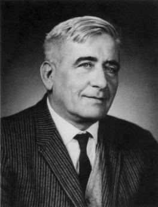

Henry Mann, PhD in Mathematics in 1935

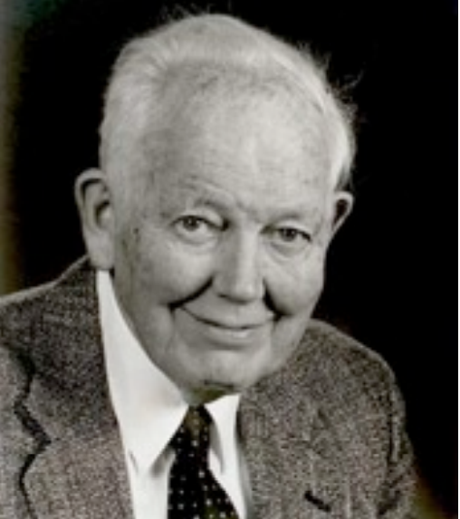

Donald Ransom Whitney, PhD in Mathematics in 1946

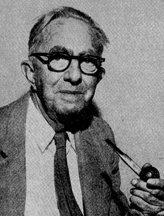

Frank Wilcoxon, PhD in Chemistry, 1924

## Other names

- Wilcoxon-Mann-Whitney
- Mann-Whitney U test
- Wilcoxon rank sum test
  - Not to be confused with Wilcoxon signed rank test

## Theory behind the Mann-Whitney-Wilcoxon test

- Combine the two groups
- Assign ranks $R(X_{ij})$
  - 1 to smallest value, 2 to second smallest, etc.
- Compute average rank, $\bar{R}$
- Compute the sum of the ranks in first group, $\Sigma R(X_{1j})$
- T = $\frac{\Sigma R(X_{1j})- n_1 \bar{R}}{se}$
  - se = $\sqrt{\frac{n_1 n_2(n_1+n_2+1)}{12}}$

## Alternate theory

- Count the times that $X_{1j}$ “wins” compared to all the $X_2$’s
  - $X_{1j}$ wins if it is larger than $X_{2k}$
  - Count ties as 0.5 (half of a “win”)
  - There are $n_1 n_2$ contests
  - U = number of wins
  - T = $\frac{U-\frac{n_1 n_2}{2}}{se}$
  - Same se as earlier slide

## Hypothetical data

```
-   X1: 34, 1695, 1193
-   X2: 652, 11, 24, 16, 1543, 39
```

## Rank sum for hypothetical data

```
Group  Outcome  Rank
    1       34     4
    1     1695     9
    1     1193     7
    2      652     6
    2       11     1
    2       24     3
    2       16     2
    2     1543     8
    2       39     5
```

- $\Sigma R(X_{1j})$ = 4 + 9 + 7 = 20
- Expected sum = 3*5 = 15

## Counting “wins” for hypothetical data

```
       652   11   24   16 1543   39
  34  Loss  Win  Win  Win Loss Loss
1695   Win  Win  Win  Win  Win  Win
1193   Win  Win  Win  Win Loss  Win
```

- U = 14 (out of 18 possible)
- Expected wins = 9

## The probability basis for ranking

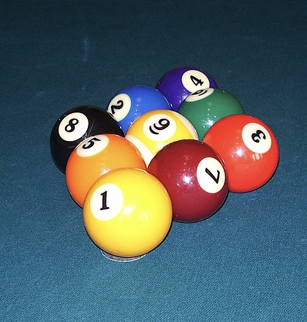

## List all the possible outcomes, 1

```
1,2,3  1,2,4  1,2,5  1,2,6  1,2,7  1,2,8  1,2,9
1,3,4  1,3,5  1,3,6  1,3,7  1,3,8  1,3,9  1,4,5
1,4,6  1,4,7  1,4,8  1,4,9  1,5,6  1,5,7  1,5,8
1,5,9  1,6,7  1,6,8  1,6,9  1,7,8  1,7,9  1,8,9
2,3,4  2,3,5  2,3,6  2,3,7  2,3,8  2,3,9  2,4,5
2,4,6  2,4,7  2,4,8  2,4,9  2,5,6  2,5,7  2,5,8
2,5,9  2,6,7  2,6,8  2,6,9  2,7,8  2,7,9  2,8,9
3,4,5  3,4,6  3,4,7  3,4,8  3,4,9  3,5,6  3,5,7
3,5,8  3,5,9  3,6,7  3,6,8  3,6,9  3,7,8  3,7,9
3,8,9  4,5,6  4,5,7  4,5,8  4,5,9  4,6,7  4,6,8
4,6,9  4,7,8  4,7,9  4,8,9  5,6,7  5,6,8  5,6,9
5,7,8  5,7,9  5,8,9  6,7,8  6,7,9  6,8,9  7,8,9
```

## List all the possible outcomes, 2

```
 6: 1,2,3
 7: 1,2,4
 8: 1,2,5  1,3,4
 9: 1,2,6  1,3,5  2,3,4
10: 1,2,7  1,3,6  1,4,5  2,3,5
11: 1,2,8  1,3,7  1,4,6  2,3,6  2,4,5
12: 1,2,9  1,3,8  1,4,7  1,5,6  2,3,7  2,4,6  3,4,5
13: 1,3,9  1,4,8  1,5,7  2,3,8  2,4,7  2,5,6  3,4,6
14: 1,4,9  1,5,8  1,6,7  2,3,9  2,4,8  2,5,7  3,4,7  3,5,6
```

## List all the possible outcomes, 3

```
15: 1,5,9  1,6,8  2,4,9  2,5,8  2,6,7  3,4,8  3,5,7  4,5,6
16: 1,6,9  1,7,8  2,5,9  2,6,8  3,4,9  3,5,8  3,6,7  4,5,7
17: 1,7,9  2,6,9  2,7,8  3,5,9  3,6,8  4,5,8  4,6,7
18: 1,8,9  2,7,9  3,6,9  3,7,8  4,5,9  4,6,8  5,6,7
19: 2,8,9  3,7,9  4,6,9  4,7,8  5,6,8
20: 3,8,9  4,7,9  5,6,9  5,7,8
21: 4,8,9  5,7,9  6,7,8
22: 5,8,9  6,7,9
23: 6,8,9
24: 7,8,9
```

## Controversy over the use of nonparametric tests

- Unclear what your hypothesis is
  - Inequality in population means
  - Inequality in population medians
  - $P[X > Y] \ne \frac{1}{2}$
- Loss of power
  - Multiply t-test sample size by pi/3.

## Log transformation

- Arithmetic mean of original data
  - $\frac{1}{n}\Sigma X_i$
- Arithmetic mean of log transformed data
  - $\frac{1}{n}\Sigma log(X_i)$
  - $\frac{1}{n} log(X_1 \times X_2 \times ... \times X_n)$
- Arithmetic mean of log transformed data back transformed
  - $(X_1 \times X_2 \times\ ...\ \times X_n)^\frac{1}{n}$
  - This is known as the geometric mean

## Break #4

- What you have learned
  - Alternative tests
- What’s coming next
  - R code for alternative tests

## simon-5501-09-demo, part 1

## Break #5

- What you have learned
  - R code for alternative tests
- What’s coming next
  - Paired data

## Paired data

- Sometimes you collect data in pairs
  - Drug for left arm, placebo for right arm
  - Measure patient before intervention and after
  - Each exposed patient matched on age/sex with control

## Calculate differences

- $D_i = X_{1i}-X_{2i}$
  - $\bar{D}=\frac{1}{n} \Sigma D_i$
  - $S_D=\sqrt{\frac{1}{n-1} \Sigma (D_i-\bar{D})^2}$

## Test of hypothesis

- $H_0:\ \mu_D = 0$
- $H_1:\ \mu_D \ne 0$
  - T = $\frac{\bar{D}}{se}$
    - $se = \frac{S_D}{\sqrt{n}}$
- Accept $H_0$ if T is close to zero.

## Confidence interval

- $\bar{D} \pm t(1-\alpha/2,df) se$
  - Range of plausible values for $\mu_D$

## Violations of the assumptions of paired t-test

- Non-linearity
- Heterogeneity
- Normality
- Independence
  - Between pairs, not within pairs

## Break #6

- What you have learned
  - Paired data
- What’s coming next
  - R code for paired data

## Break #7

- What you have learned
  - R code for paired data
- What’s coming next
  - Your homework

## simon-5501-09-directions.md

## Summary

- What you have learned
  - Restructuring your data
  - One-tailed tests
  - Checking assumptions
  - Alternative tests
  - R code for alternative tests
  - Paired data
  - R code for paired data
  - Your homework